[figure not shown]

## Análisis de Promulgación de Leyes en el Congreso Peruano

#### Elaborado por el Laboratorio de Políticas Públicas de la PUCP

**Índice**

#### Introducción

El siguiente ejercicio evalúa la promulgación de leyes de los últimos 5 periodos parlamentarios. En total, se analizaron **34 587 propuestas de ley.**

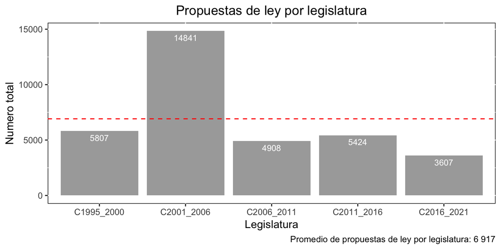

### Análisis periodo 1995-2000

En la siguiente sección, se analizan las **5 807 leyes propuestas** durante el periodo legislativo 1995-2000.

#### Proponentes

La siguiente tabla muestra el número de leyes propuestas por tipo de proponente y el número de leyes promulgadas por tipo de proponente.

|  | proponenteR | N_Leyes | N_Leyes_Promulgadas |
| --- | --- | --- | --- |
| 1 | Congreso | 5231 | 1133 |
| 2 | Poder Ejecutivo | 427 | 335 |
| 3 | Gobiernos Locales | 66 | 5 |
| 4 | Colegios Profesionales | 35 | 2 |
| 5 | Fiscalia | 11 | 3 |
| 6 | CNM | 8 | 5 |
| 7 | JNE | 7 | 2 |
| 8 | Poder Judicial | 7 | 2 |
| 9 | ONPE | 4 | 1 |
| 10 | BCR | 3 | 1 |

[output cut: 4 more lines]

El siguiente gráfico muestra el estado de las leyes propuestas por tipo de proponente.

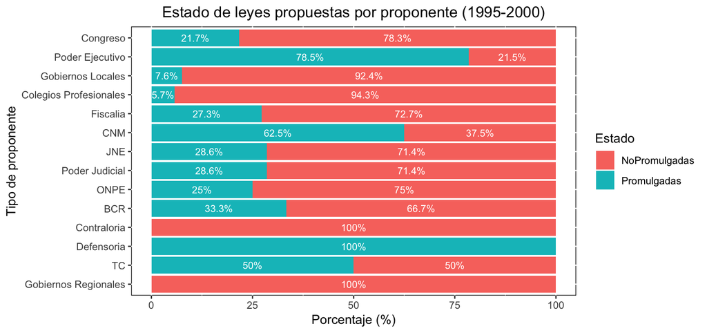

El siguiente gráfico muestra el tiempo promedio para que una ley sea promulgada por tipo de proponente [Se consideran únicamente a las leyes promulgadas para el análisis].

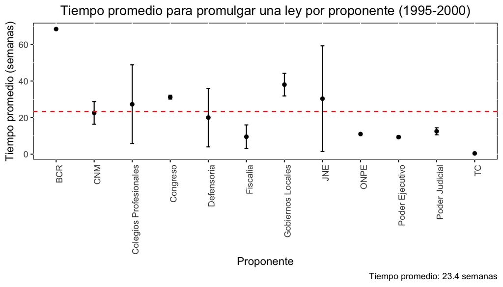

#### Grupos parlamentarios

|  | grupoParlamentarioR | N_Leyes | N_Leyes_Promulgadas |
| --- | --- | --- | --- |
| 1 |  | 5752 | 1440 |
| 2 | Grupo Fujimorista | 38 | 35 |
| 3 | Multipartidario | 9 | 9 |
| 4 | Union por el Peru | 5 | 5 |
| 5 | Partido Aprista Peruano | 2 | 2 |
| 6 | No Agrupados | 1 | 1 |

El siguiente gráfico muestra el estado de las leyes propuestas por grupo parlamentario.

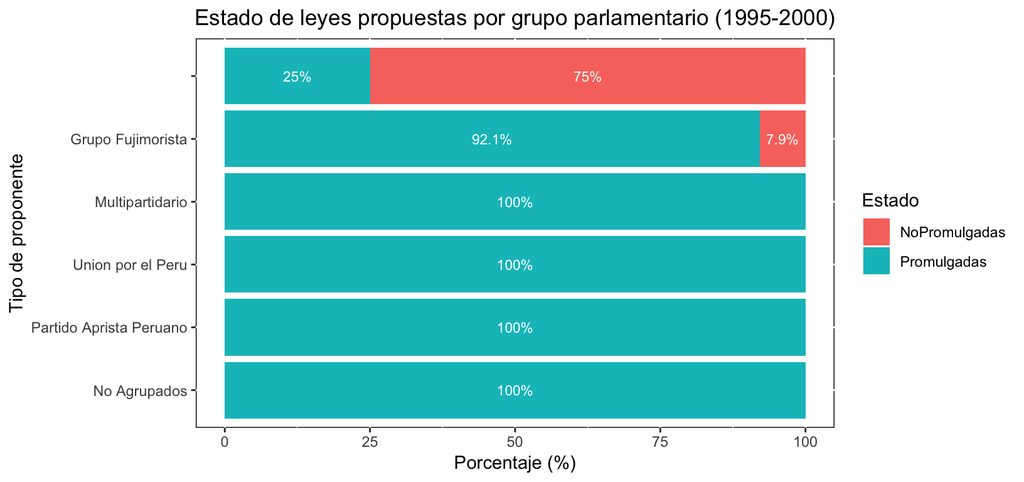

El siguiente gráfico muestra el tiempo promedio para que una ley sea promulgada por grupo parlamentario [Se consideran únicamente a las leyes promulgadas para el análisis].

[figure not shown]

#### Análisis del contenido de Leyes Propuestas

**Leyes promulgadas**

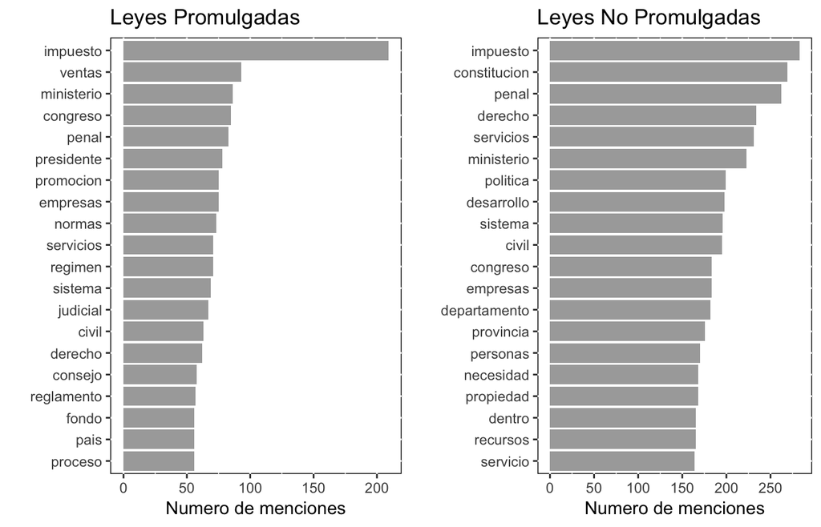

**El equipo del LabPUCP está conformado por:**

- Director: Dr. José Manuel Magallanes
- Investigadora Senior: Lic. María Gracia Becerra
- Investigador Junior: Alexander Benites